# Part 1. Reading Data

## Balanced data is ready now.

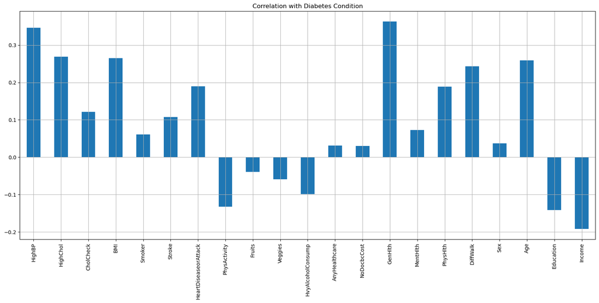

```python
#check the corellation between the attributes and the target (Diabetics_012)

train_data_balanced = pd.concat([Y_train_resampled, X_train_resampled], axis=1)

train_data_balanced.drop('Diabetes_01', axis=1).corrwith(train_data_balanced.Diabetes_01).plot(kind='bar', grid=True, figsize=(20, 8), title="Correlation with Diabetes Condition", color='#1f77b4');
```

```python
# check the distribution of each category based on features separetaly.

train_data_balanced = pd.concat([Y_train_resampled, X_train_resampled], axis=1)

#cols = ['HighBP', 'HighChol', 'BMI','Stroke', 'HeartDiseaseorAttack',
 #      'GenHlth', 'PhysHlth', 'DiffWalk', 'PhysActivity', 'Age',
  #     'Education', 'Income']

cols = train_data_balanced.columns[1:]

def create_plot_pivot(train_data_balanced, x_column):
    """ Create a pivot table for satisfaction versus another rating for easy plotting. """
    _df_plot = train_data_balanced.groupby([x_column, 'Diabetes_01']).size() \
    .reset_index().pivot(columns='Diabetes_01', index=x_column, values=0)
    return _df_plot
```

```python
train_data_balanced.head()
```

|  | Diabetes_01 | HighBP | HighChol | CholCheck | BMI | Smoker | Stroke | HeartDiseaseorAttack | PhysActivity | Fruits | ... | AnyHealthcare | NoDocbcCost | GenHlth | MentHlth | PhysHlth | DiffWalk | Sex | Age | Education | Income |
| --- | --- | --- | --- | --- | --- | --- | --- | --- | --- | --- | --- | --- | --- | --- | --- | --- | --- | --- | --- | --- | --- |
| 144243 | 0 | 0 | 0 | 1 | 21 | 1 | 0 | 0 | 1 | 0 | ... | 1 | 1 | 1 | 0 | 0 | 0 | 0 | 10 | 4 | 5 |
| 232663 | 0 | 0 | 0 | 1 | 35 | 0 | 0 | 0 | 0 | 1 | ... | 1 | 0 | 2 | 0 | 0 | 0 | 0 | 11 | 6 | 8 |
| 78541 | 0 | 0 | 0 | 1 | 25 | 0 | 0 | 0 | 1 | 0 | ... | 1 | 0 | 1 | 0 | 1 | 0 | 1 | 5 | 6 | 8 |
| 15030 | 0 | 0 | 0 | 0 | 22 | 0 | 0 | 0 | 1 | 1 | ... | 1 | 0 | 2 | 0 | 0 | 0 | 0 | 5 | 6 | 8 |
| 937 | 0 | 1 | 1 | 1 | 29 | 0 | 0 | 0 | 1 | 1 | ... | 1 | 0 | 4 | 2 | 30 | 1 | 0 | 9 | 3 | 2 |

5 rows × 22 columns

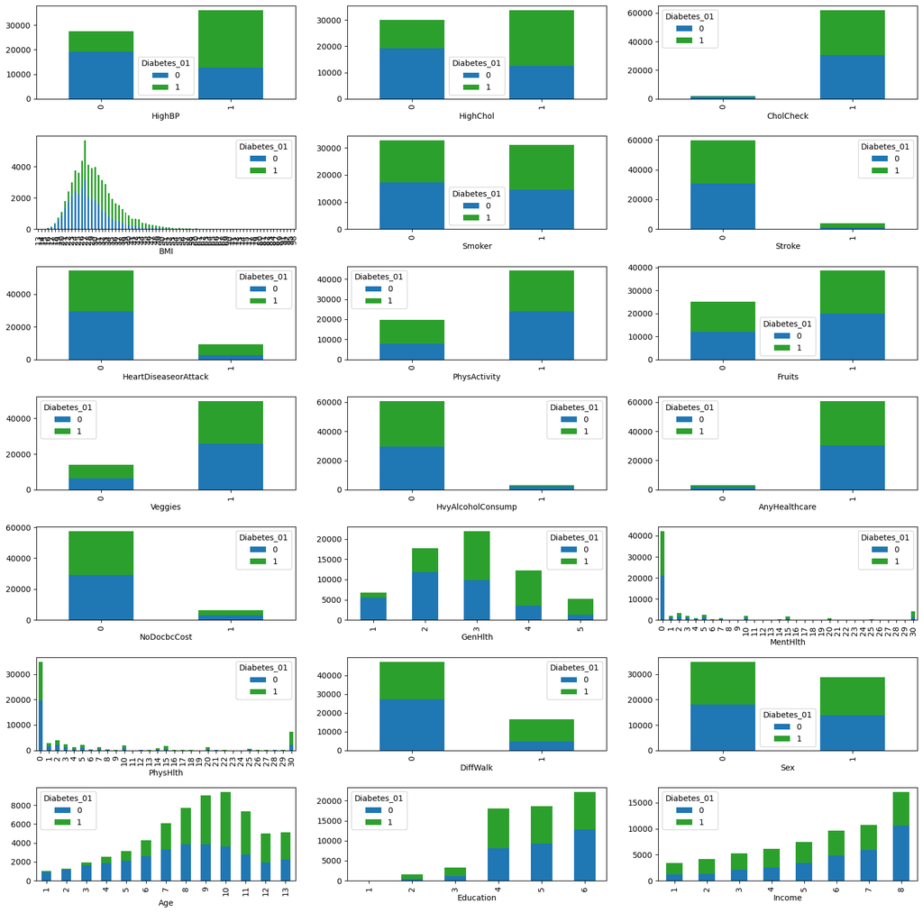

```python
fig, ax = plt.subplots(7, 3, figsize=(20,20))
axe = ax.ravel()

c = len(cols)
colors = ['#1f77b4', '#2ca02c']

for i in range(c):
    create_plot_pivot(train_data_balanced, cols[i]).plot(kind='bar',stacked=True, ax=axe[i], color=colors)
    axe[i].set_xlabel(cols[i])

fig.show()
plt.subplots_adjust(hspace=0.4)  # Increase vertical spacing between subplots
```

# Part 5. Feature selection

```python
#apply SelectKBest class to extract best features

from sklearn.feature_selection import SelectKBest
from sklearn.feature_selection import chi2
from sklearn.datasets import make_classification
from sklearn.feature_selection import SelectKBest


BestFeatures = SelectKBest(score_func=chi2, k=10)
fit = BestFeatures.fit(X_train_resampled,Y_train_resampled)

df_scores = pd.DataFrame(fit.scores_)
df_columns = pd.DataFrame(X_train_resampled.columns)

#concatenating two dataframes for better visualization

f_Scores = pd.concat([df_columns,df_scores],axis=1)               # feature scores
f_Scores.columns = ['Feature','Score']

f_Scores
```

|  | Feature | Score |
| --- | --- | --- |
| 0 | HighBP | 3262.230718 |
| 1 | HighChol | 2163.563987 |
| 2 | CholCheck | 24.338791 |
| 3 | BMI | 7780.031431 |
| 4 | Smoker | 116.790300 |
| 5 | Stroke | 772.097960 |
| 6 | HeartDiseaseorAttack | 2002.134136 |
| 7 | PhysActivity | 341.087411 |
| 8 | Fruits | 26.953561 |
| 9 | Veggies | 46.340426 |
| 10 | HvyAlcoholConsump | 546.061471 |
| 11 | AnyHealthcare | 4.093151 |
| 12 | NoDocbcCost | 61.907741 |
| 13 | GenHlth | 3568.406077 |
| 14 | MentHlth | 5865.738815 |
| 15 | PhysHlth | 39850.528297 |
| 16 | DiffWalk | 2939.871471 |
| 17 | Sex | 55.273599 |
| 18 | Age | 4307.061953 |
| 19 | Education | 292.149215 |
| 20 | Income | 1985.450667 |

```python
#finding the 12 feautures with highest scores to choose in our models.

f_Scores.nlargest(21,'Score')
```

|  | Feature | Score |
| --- | --- | --- |
| 15 | PhysHlth | 39850.528297 |
| 3 | BMI | 7780.031431 |
| 14 | MentHlth | 5865.738815 |
| 18 | Age | 4307.061953 |
| 13 | GenHlth | 3568.406077 |
| 0 | HighBP | 3262.230718 |
| 16 | DiffWalk | 2939.871471 |
| 1 | HighChol | 2163.563987 |
| 6 | HeartDiseaseorAttack | 2002.134136 |
| 20 | Income | 1985.450667 |
| 5 | Stroke | 772.097960 |
| 10 | HvyAlcoholConsump | 546.061471 |
| 7 | PhysActivity | 341.087411 |
| 19 | Education | 292.149215 |
| 4 | Smoker | 116.790300 |
| 12 | NoDocbcCost | 61.907741 |
| 17 | Sex | 55.273599 |
| 9 | Veggies | 46.340426 |
| 8 | Fruits | 26.953561 |
| 2 | CholCheck | 24.338791 |
| 11 | AnyHealthcare | 4.093151 |

```python
#dropping the low score features from our dataframe

#choose the list of columns to be dropped as you wish based on the correlation or the f-score. Dont Forget to comment the rest!!!!!!!

#keeping 10 feautures with highest correlation and f-score
columns = ['Fruits', 'Veggies', 'Sex', 'CholCheck', 'AnyHealthcare', 'Education', 'Smoker', 'NoDocbcCost', 'PhysActivity', 'MentHlth', 'HvyAlcoholConsump']
train_balanced_reduced = train_data_balanced.drop(columns=columns, axis=1)
X_test_reduced = X_test.drop(columns=columns, axis=1)

# #keeping 12 feautures with highest correlation.
# columns = ['Fruits', 'Veggies', 'Sex', 'CholCheck', 'AnyHealthcare', 'HvyAlcoholConsump', 'Smoker', 'NoDocbcCost', 'MentHlth']
# train_balanced_reduced = train_data_balanced.drop(columns=columns, axis=1)
# X_test_reduced = X_test.drop(columns=columns, axis=1)

# #keeping 12 feautures with highest f-score.
# columns = ['Fruits', 'Veggies', 'Sex', 'CholCheck', 'AnyHealthcare', 'Education', 'Smoker', 'NoDocbcCost', 'PhysActivity']
# train_balanced_reduced = train_data_balanced.drop(columns=columns, axis=1)
# X_test_reduced = X_test.drop(columns=columns, axis=1)

#keeping 14 feautures with highst correlation and f-score.
#columns = ['Fruits', 'Veggies', 'Sex', 'CholCheck', 'AnyHealthcare', 'Sex', 'HvyAlcoholConsump']
#train_balanced_reduced = train_data_balanced.drop(columns=columns, axis=1)
#X_test_reduced = X_test.drop(columns=columns, axis=1)

#keeping 17 feautures with highst correlation and f-score.
#columns = ['AnyHealthcare', 'CholCheck', 'Stroke' , 'Smoker' ]
#train_balanced_reduced = train_data_balanced.drop(columns=columns, axis=1)
#X_test_reduced = X_test.drop(columns=columns, axis=1)
```

```python
train_balanced_reduced.columns
```

[output not shown]

```python
train_balanced_reduced.head()
```

[output not shown]

```python
train_balanced_reduced.info()
```

[output not shown]

```python
X_train_resampled
```

|  | HighBP | HighChol | CholCheck | BMI | Smoker | Stroke | HeartDiseaseorAttack | PhysActivity | Fruits | Veggies | ... | AnyHealthcare | NoDocbcCost | GenHlth | MentHlth | PhysHlth | DiffWalk | Sex | Age | Education | Income |
| --- | --- | --- | --- | --- | --- | --- | --- | --- | --- | --- | --- | --- | --- | --- | --- | --- | --- | --- | --- | --- | --- |
| 158785 | 0 | 0 | 1 | 37 | 1 | 0 | 0 | 1 | 0 | 1 | ... | 1 | 0 | 3 | 0 | 30 | 1 | 0 | 11 | 4 | 6 |
| 106334 | 0 | 0 | 1 | 22 | 1 | 0 | 0 | 1 | 1 | 1 | ... | 1 | 0 | 2 | 0 | 0 | 1 | 0 | 9 | 4 | 6 |
| 26222 | 0 | 0 | 1 | 28 | 1 | 0 | 0 | 1 | 1 | 1 | ... | 1 | 0 | 2 | 0 | 0 | 0 | 1 | 4 | 5 | 7 |
| 167230 | 1 | 0 | 1 | 26 | 0 | 0 | 0 | 1 | 1 | 1 | ... | 1 | 0 | 2 | 10 | 0 | 0 | 1 | 3 | 6 | 8 |
| 249945 | 1 | 1 | 1 | 29 | 0 | 0 | 0 | 0 | 0 | 1 | ... | 1 | 1 | 3 | 0 | 0 | 0 | 0 | 8 | 5 | 3 |
| ... | ... | ... | ... | ... | ... | ... | ... | ... | ... | ... | ... | ... | ... | ... | ... | ... | ... | ... | ... | ... | ... |
| 181746 | 0 | 0 | 1 | 26 | 1 | 0 | 1 | 1 | 1 | 1 | ... | 0 | 0 | 3 | 0 | 5 | 0 | 1 | 5 | 4 | 2 |
| 140764 | 0 | 0 | 1 | 35 | 1 | 0 | 0 | 0 | 0 | 1 | ... | 1 | 0 | 4 | 0 | 3 | 0 | 1 | 10 | 5 | 7 |
| 170522 | 1 | 1 | 1 | 37 | 0 | 0 | 1 | 0 | 0 | 1 | ... | 1 | 0 | 4 | 0 | 2 | 0 | 0 | 10 | 5 | 4 |
| 68251 | 1 | 0 | 1 | 32 | 0 | 1 | 1 | 1 | 1 | 1 | ... | 1 | 0 | 3 | 3 | 0 | 1 | 0 | 11 | 5 | 3 |
| 121172 | 1 | 1 | 1 | 34 | 0 | 0 | 0 | 1 | 1 | 1 | ... | 1 | 0 | 5 | 0 | 30 | 1 | 1 | 12 | 4 | 2 |

63770 rows × 21 columns

# Part 6: Modeling

Now we can choose to apply the ML algorithms on the primary imbalanced data (X_train, Y_train), or on balanced data (X_train_resampled, Y_train_resampled), or on reduced balanced data (X-train_reduced, Y_train_reduced). Please note that in case of using the reduced balanced data, you need to use the reduced test dataset (X_test_reduced, Y_test) for evaluation of the modeling.

```python
#choose one of the following datasets for modeling and dont forget to comment the rest!!!!!

# #primary imbalanced data
# X_train
# Y_train
# X_test
# Y_test

#balanced data
#X_train = X_train_resampled
#Y_train = Y_train_resampled
#X_test
#Y_test

# #reduced balanced data
X_train = train_balanced_reduced.iloc[:, 1:]
Y_train = train_balanced_reduced.iloc[:, :1]
X_test = X_test_reduced
Y_test = Y_test
```

```python
# print(train_balanced_reduced.head())
# print(X_train.head())
# Y_train.head()
```

## Data Scaling

```python
#Data Scaling

from sklearn.preprocessing import StandardScaler

scalar = StandardScaler()
X_train = scalar.fit_transform(X_train)
X_test = scalar.fit_transform(X_test)
```

```python
#imports

from sklearn.metrics import mean_absolute_error , mean_absolute_percentage_error , mean_squared_error , accuracy_score
from sklearn.ensemble import RandomForestClassifier
from sklearn.neighbors import KNeighborsClassifier
from sklearn.tree import DecisionTreeClassifier
from sklearn.linear_model import LogisticRegression
%matplotlib inline
from tqdm import tqdm
```

```python
from sklearn.metrics import f1_score
```

# Model 1: Logistic Regression

##### Finding the best parameters for the logistic regression model with balanced data using the SMOTE-ENN algorithm.

```python
from sklearn.model_selection import GridSearchCV
from sklearn.linear_model import LogisticRegression
from sklearn.metrics import make_scorer, f1_score


model = LogisticRegression()


param_grid = {
    'C': np.logspace(-4, 4, 10),
    'penalty': ['l1', 'l2'],
    'solver': ['liblinear', 'lbfgs', 'saga'],
    'max_iter': np.arange(100, 1000, 100)
}
scorer = make_scorer(f1_score, average='weighted')

grid_search = GridSearchCV(model, param_grid, cv=5, n_jobs=-1, verbose=2, scoring=scorer)


grid_search.fit(X_train, Y_train)


print("Best Parameters:", grid_search.best_params_)
print("Best Score:", grid_search.best_score_)
```

```
Fitting 5 folds for each of 540 candidates, totalling 2700 fits
Best Parameters: {'C': 166.81005372000558, 'max_iter': 300, 'penalty': 'l2', 'solver': 'lbfgs'}
Best Score: 0.855632693678569
```

Best Parameters: {'C': 166.81005372000558, 'max_iter': 300, 'penalty': 'l2', 'solver': 'lbfgs'} Best Score: 0.855632693678569

```python
#lg_results = {}
```

Changing the parameters of logistic regression here doesn't have a significant impact on the code. Therefore, we train the rest of the models with different data balancing algorithms using the same parameters.

### Logistic Regression: with 17 features SMOTE-ENN

```python
logReg = LogisticRegression(C = 166.81005372000558, max_iter = 300, penalty = 'l2', solver = 'lbfgs')
logReg.fit(X_train, Y_train)
y_pred = logReg.predict(X_test)
acc = accuracy_score(Y_test, y_pred)
f1_score_class_1 = f1_score(Y_test, y_pred, pos_label=1)
f1_score_class_0 = f1_score(Y_test, y_pred, pos_label=0)
f1_score_weighted_avg = f1_score(Y_test, y_pred, average='weighted')
f1_score_macro_avg = f1_score(Y_test, y_pred, average='macro')
lg_results['SMOTE-ENN'] = {'accuracy': acc, 'F1-score class_1': f1_score_class_1 ,'f1 score class_0' : f1_score_class_0, 'f1_score weighted_avg' : f1_score_weighted_avg ,'f1_score macro_avg':f1_score_macro_avg}
print("accuracy is: ", acc)
print('Training set score: {:.4f}'.format(logReg.score(X_train, Y_train)))
print('Test set score: {:.4f}'.format(logReg.score(X_test, Y_test)))
```

```
accuracy is:  0.6118980786387275
Training set score: 0.8575
Test set score: 0.6119
```

### Logistic Regression: with 17 features SMOTE

```python
logReg = LogisticRegression(C = 166.81005372000558, max_iter = 300, penalty = 'l2', solver = 'lbfgs')
logReg.fit(X_train, Y_train)
y_pred = logReg.predict(X_test)
acc = accuracy_score(Y_test, y_pred)
f1_score_class_1 = f1_score(Y_test, y_pred, pos_label=1)
f1_score_class_0 = f1_score(Y_test, y_pred, pos_label=0)
f1_score_weighted_avg = f1_score(Y_test, y_pred, average='weighted')
f1_score_macro_avg = f1_score(Y_test, y_pred, average='macro')
lg_results['SMOTE'] = {'accuracy': acc, 'F1-score class_1': f1_score_class_1 ,'f1 score class_0' : f1_score_class_0, 'f1_score weighted_avg' : f1_score_weighted_avg ,'f1_score macro_avg':f1_score_macro_avg}
print("accuracy is: ", acc)
print('Training set score: {:.4f}'.format(logReg.score(X_train, Y_train)))
print('Test set score: {:.4f}'.format(logReg.score(X_test, Y_test)))
```

```
accuracy is:  0.7189981939639228
Training set score: 0.7362
Test set score: 0.7190
```

### Logistic Regression: with 17 features NearMiss

```python
logReg = LogisticRegression(C = 166.81005372000558, max_iter = 300, penalty = 'l2', solver = 'lbfgs')
logReg.fit(X_train, Y_train)
y_pred = logReg.predict(X_test)
acc = accuracy_score(Y_test, y_pred)
f1_score_class_1 = f1_score(Y_test, y_pred, pos_label=1)
f1_score_class_0 = f1_score(Y_test, y_pred, pos_label=0)
f1_score_weighted_avg = f1_score(Y_test, y_pred, average='weighted')
f1_score_macro_avg = f1_score(Y_test, y_pred, average='macro')
lg_results['NearMiss'] = {'accuracy': acc, 'F1-score class_1': f1_score_class_1 ,'f1 score class_0' : f1_score_class_0, 'f1_score weighted_avg' : f1_score_weighted_avg ,'f1_score macro_avg':f1_score_macro_avg}
print("accuracy is: ", acc)
print('Training set score: {:.4f}'.format(logReg.score(X_train, Y_train)))
print('Test set score: {:.4f}'.format(logReg.score(X_test, Y_test)))
```

```
accuracy is:  0.7189981939639228
Training set score: 0.7362
Test set score: 0.7190
```

### Logistic Regression: with 17 features Random down-Sampling

```python
logReg = LogisticRegression(C = 166.81005372000558, max_iter = 300, penalty = 'l2', solver = 'lbfgs')
logReg.fit(X_train, Y_train)
y_pred = logReg.predict(X_test)
acc = accuracy_score(Y_test, y_pred)
f1_score_class_1 = f1_score(Y_test, y_pred, pos_label=1)
f1_score_class_0 = f1_score(Y_test, y_pred, pos_label=0)
f1_score_weighted_avg = f1_score(Y_test, y_pred, average='weighted')
f1_score_macro_avg = f1_score(Y_test, y_pred, average='macro')
lg_results['Random'] = {'accuracy': acc, 'F1-score class_1': f1_score_class_1 ,'f1 score class_0' : f1_score_class_0, 'f1_score weighted_avg' : f1_score_weighted_avg ,'f1_score macro_avg':f1_score_macro_avg}
print("accuracy is: ", acc)
print('Training set score: {:.4f}'.format(logReg.score(X_train, Y_train)))
print('Test set score: {:.4f}'.format(logReg.score(X_test, Y_test)))
```

```
accuracy is:  0.718454207193681
Training set score: 0.7254
Test set score: 0.7185
```

### Logistic Regression: with weighting

```python
# Calculate the class weights
class_weight1 =dict({0:0.6, 1:2.8}) # Set the weight of the minority class to 10

# Train a logistic regression model with class weights
logReg = LogisticRegression( max_iter = 300, class_weight= class_weight1)
logReg.fit(X_train , Y_train)

# make predictions on test set
y_pred=logReg.predict(X_test)
lg_predictions = y_pred
acc = accuracy_score(Y_test, y_pred)
f1_score_class_1 = f1_score(Y_test, y_pred, pos_label=1)
f1_score_class_0 = f1_score(Y_test, y_pred, pos_label=0)
f1_score_weighted_avg = f1_score(Y_test, y_pred, average='weighted')
f1_score_macro_avg = f1_score(Y_test, y_pred, average='macro')
lg_results['weighting'] = {'accuracy': acc, 'F1-score class_1': f1_score_class_1 ,'f1 score class_0' : f1_score_class_0, 'f1_score weighted_avg' : f1_score_weighted_avg ,'f1_score macro_avg':f1_score_macro_avg}
print("accuracy is: ", acc)
print('Training set score: {:.4f}'.format(logReg.score(X_train, Y_train)))
print('Test set score: {:.4f}'.format(logReg.score(X_test, Y_test)))
```

```
accuracy is:  0.7218704441107993
Training set score: 0.7186
Test set score: 0.7219
```

```python
lg_results
```

```
{'SMOTE-ENN': {'accuracy': 0.6118980786387275,
  'F1-score class_1': 0.43589094819406676,
  'f1 score class_0': 0.7041926495953297,
  'f1_score weighted_avg': 0.6584160836600575,
  'f1_score macro_avg': 0.5700417988946982},
 'SMOTE': {'accuracy': 0.7189981939639228,
  'F1-score class_1': 0.47371423913929417,
  'f1 score class_0': 0.8083293754452624,
  'f1_score weighted_avg': 0.7512386757961317,
  'f1_score macro_avg': 0.6410218072922783},
 'NearMiss': {'accuracy': 0.7189981939639228,
  'F1-score class_1': 0.47371423913929417,
  'f1 score class_0': 0.8083293754452624,
  'f1_score weighted_avg': 0.7512386757961317,
  'f1_score macro_avg': 0.6410218072922783},
 'Random': {'accuracy': 0.718454207193681,
  'F1-score class_1': 0.4742594774694243,
  'f1 score class_0': 0.8077500260018127,
  'f1_score weighted_avg': 0.7508511990322007,
  'f1_score macro_avg': 0.6410047517356185},
 'weighting': {'accuracy': 0.7218704441107993,
  'F1-score class_1': 0.477047704770477,
  'f1 score class_0': 0.8105584538771639,
  'f1_score weighted_avg': 0.7536561803661529,
  'f1_score macro_avg': 0.6438030793238204}}
```

#### saving lg-results

```python
'''
lg_results_df = pd.DataFrame.from_dict(lg_results, orient='index')
csv_filename = "lg_results.csv"
lg_results_df.to_csv(csv_filename, index=False)
'''
```

If you do not want to re-run and find the model parameter, by uncommenting the following cell and running it, you can observe the results and scores of the Logisitic regression model for different parameters. First, download the 'lg_results.csv' file and place it in the directory of this notebook.

```python
'''
lg_results_df = pd.read_csv('lg_results.csv')
lg_results = lg_results_df.to_dict(orient='index')
'''
```

#### Displaying the changes in accuracy and F1 score of the model

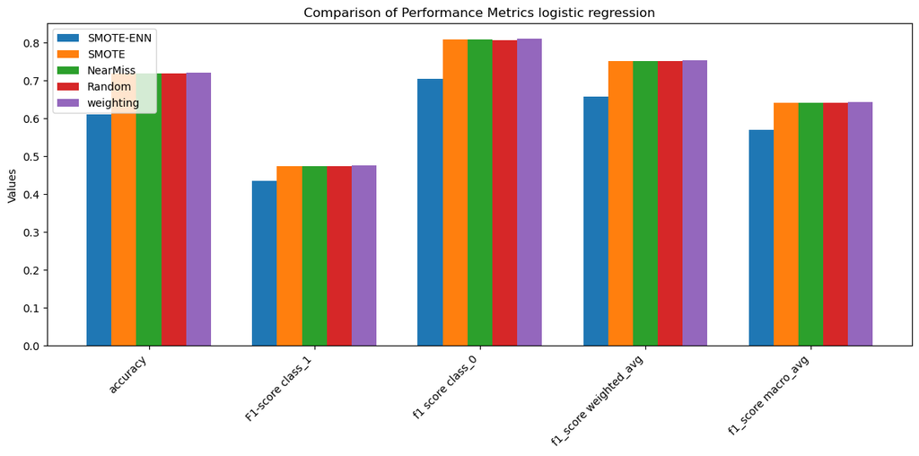

```python
import matplotlib.pyplot as plt

data ={'SMOTE-ENN': {'accuracy': 0.6118980786387275,
  'F1-score class_1': 0.43589094819406676,
  'f1 score class_0': 0.7041926495953297,
  'f1_score weighted_avg': 0.6584160836600575,
  'f1_score macro_avg': 0.5700417988946982},
 'SMOTE': {'accuracy': 0.7189981939639228,
  'F1-score class_1': 0.47371423913929417,
  'f1 score class_0': 0.8083293754452624,
  'f1_score weighted_avg': 0.7512386757961317,
  'f1_score macro_avg': 0.6410218072922783},
 'NearMiss': {'accuracy': 0.7189981939639228,
  'F1-score class_1': 0.47371423913929417,
  'f1 score class_0': 0.8083293754452624,
  'f1_score weighted_avg': 0.7512386757961317,
  'f1_score macro_avg': 0.6410218072922783},
 'Random': {'accuracy': 0.718454207193681,
  'F1-score class_1': 0.4742594774694243,
  'f1 score class_0': 0.8077500260018127,
  'f1_score weighted_avg': 0.7508511990322007,
  'f1_score macro_avg': 0.6410047517356185},
 'weighting': {'accuracy': 0.7218704441107993,
  'F1-score class_1': 0.477047704770477,
  'f1 score class_0': 0.8105584538771639,
  'f1_score weighted_avg': 0.7536561803661529,
  'f1_score macro_avg': 0.6438030793238204}}

categories = list(data['SMOTE-ENN'].keys())
num_models = len(data)
width = 0.15
positions = list(range(len(categories)))

plt.figure(figsize=(12, 6))

for i, (model, values) in enumerate(data.items()):
    values = [values.get(key, 0) for key in categories]
    plt.bar([pos + width * i for pos in positions], values, width, label=model)

#plt.xlabel('Metrics')
plt.ylabel('Values')
plt.title('Comparison of Performance Metrics logistic regression')
plt.xticks([pos + width * 2 for pos in positions], categories, rotation=45, ha='right')
plt.legend()
plt.tight_layout()
plt.show()
```

### choosing the best logistic regression model

logistic regression with weightening and max-iter = 300

```python
# make predictions on test set

# Calculate the class weights
class_weight1 =dict({0:0.6, 1:2.8}) # Set the weight of the minority class to 10

# Train a logistic regression model with class weights
logReg = LogisticRegression( max_iter = 300, class_weight= class_weight1)
logReg.fit(X_train , Y_train)

# make predictions on test set
y_pred=logReg.predict(X_test)
lg_predictions = y_pred

#print('Training set score: {:.4f}'.format(lg.score(X_train, Y_train)))

#print('Test set score: {:.4f}'.format(lg.score(X_test, Y_test)))
```

```python
#check MSE & RMSE

import math

mse =mean_squared_error(Y_test, y_pred)
print('Mean Squared Error : '+ str(mse))
rmse = math.sqrt(mean_squared_error(Y_test, y_pred))
print('Root Mean Squared Error : '+ str(rmse))
```

```
Mean Squared Error : 0.2781295558892008
Root Mean Squared Error : 0.5273798971227485
```

```python
from sklearn.metrics import confusion_matrix, classification_report

matrix = classification_report(Y_test,y_pred )
print(matrix)
```

```
              precision    recall  f1-score   support

           0       0.93      0.72      0.81     38116
           1       0.35      0.74      0.48      7841

    accuracy                           0.72     45957
   macro avg       0.64      0.73      0.64     45957
weighted avg       0.83      0.72      0.75     45957
```

[figure not shown]

```python
# calculating and plotting the confusion matrix

from mlxtend.plotting import plot_confusion_matrix

cm1 = confusion_matrix(Y_test,y_pred)
plot_confusion_matrix(conf_mat=cm1,show_absolute=True,
                                show_normed=True,
                                colorbar=True)
plt.show()
```

# Model 2: Decision Tree

The optimization of this model's parameters has been performed using the data balancing technique along with the grid search method.

```python
#dt_results = {}
```

### Random down-Sampling with feature selection (10 features)

DecisionTreeClassifier(criterion='entropy', max_depth=7, min_samples_leaf=2)

```python
dt_classifier = DecisionTreeClassifier(criterion='entropy', max_depth=7, min_samples_leaf=2)
dt_classifier.fit(X_train , Y_train)

# make predictions on test set
y_pred=dt_classifier.predict(X_test)
dt_predictions = y_pred
acc = accuracy_score(Y_test, y_pred)
f1_score_class_1 = f1_score(Y_test, y_pred, pos_label=1)
f1_score_class_0 = f1_score(Y_test, y_pred, pos_label=0)
f1_score_weighted_avg = f1_score(Y_test, y_pred, average='weighted')
f1_score_macro_avg = f1_score(Y_test, y_pred, average='macro')
dt_results['RS FS'] = {'accuracy': acc, 'F1-score class_1': f1_score_class_1 ,'f1 score class_0' : f1_score_class_0, 'f1_score weighted_avg' : f1_score_weighted_avg ,'f1_score macro_avg':f1_score_macro_avg}
print("accuracy is: ", acc)
print('Training set score: {:.4f}'.format(dt_classifier.score(X_train, Y_train)))
print('Test set score: {:.4f}'.format(dt_classifier.score(X_test, Y_test)))
```

```
accuracy is:  0.7038536022803925
Training set score: 0.7271
Test set score: 0.7039
```

The results of this model do not show a noticeable change without removing 10 features.

### NearMiss algorithm with feature selection (10 features)

DecisionTreeClassifier(max_depth=7)

```python
dt_classifier = DecisionTreeClassifier( max_depth=7)
dt_classifier.fit(X_train , Y_train)

# make predictions on test set
y_pred=dt_classifier.predict(X_test)
dt_predictions = y_pred
acc = accuracy_score(Y_test, y_pred)
f1_score_class_1 = f1_score(Y_test, y_pred, pos_label=1)
f1_score_class_0 = f1_score(Y_test, y_pred, pos_label=0)
f1_score_weighted_avg = f1_score(Y_test, y_pred, average='weighted')
f1_score_macro_avg = f1_score(Y_test, y_pred, average='macro')
dt_results['NM FS'] = {'accuracy': acc, 'F1-score class_1': f1_score_class_1 ,'f1 score class_0' : f1_score_class_0, 'f1_score weighted_avg' : f1_score_weighted_avg ,'f1_score macro_avg':f1_score_macro_avg}
print("accuracy is: ", acc)
print('Training set score: {:.4f}'.format(dt_classifier.score(X_train, Y_train)))
print('Test set score: {:.4f}'.format(dt_classifier.score(X_test, Y_test)))
```

```
accuracy is:  0.5452488195487086
Training set score: 0.8186
Test set score: 0.5452
```

The results of this model do not show a noticeable change without removing 10 features. DecisionTreeClassifier(max_depth=7, min_samples_leaf=2)

### SMOTE algorithm with feature selection (14 features)

DecisionTreeClassifier(max_depth=7, min_samples_leaf=2, min_samples_split=10)

```python
dt_classifier = DecisionTreeClassifier(max_depth=7, min_samples_leaf=2, min_samples_split=10)
dt_classifier.fit(X_train , Y_train)

# make predictions on test set
y_pred=dt_classifier.predict(X_test)
dt_predictions = y_pred
acc = accuracy_score(Y_test, y_pred)
f1_score_class_1 = f1_score(Y_test, y_pred, pos_label=1)
f1_score_class_0 = f1_score(Y_test, y_pred, pos_label=0)
f1_score_weighted_avg = f1_score(Y_test, y_pred, average='weighted')
f1_score_macro_avg = f1_score(Y_test, y_pred, average='macro')
dt_results['SMOTE FS'] = {'accuracy': acc, 'F1-score class_1': f1_score_class_1 ,'f1 score class_0' : f1_score_class_0, 'f1_score weighted_avg' : f1_score_weighted_avg ,'f1_score macro_avg':f1_score_macro_avg}
print("accuracy is: ", acc)
print('Training set score: {:.4f}'.format(dt_classifier.score(X_train, Y_train)))
print('Test set score: {:.4f}'.format(dt_classifier.score(X_test, Y_test)))
```

```
accuracy is:  0.492155710773114
Training set score: 0.8350
Test set score: 0.4922
```

The results of this model show improvement when compared to not removing the 14 features.

DecisionTreeClassifier(max_depth=7, min_samples_leaf=2)

### SMOTE-ENN algorithm with feature selection (17 features)

DecisionTreeClassifier(max_depth=7, min_samples_leaf=2)

```python
dt_classifier = DecisionTreeClassifier(max_depth=7, min_samples_leaf=2)
dt_classifier.fit(X_train , Y_train)

# make predictions on test set
y_pred=dt_classifier.predict(X_test)
dt_predictions = y_pred
acc = accuracy_score(Y_test, y_pred)
f1_score_class_1 = f1_score(Y_test, y_pred, pos_label=1)
f1_score_class_0 = f1_score(Y_test, y_pred, pos_label=0)
f1_score_weighted_avg = f1_score(Y_test, y_pred, average='weighted')
f1_score_macro_avg = f1_score(Y_test, y_pred, average='macro')
dt_results['SMOTE-ENN FS'] = {'accuracy': acc, 'F1-score class_1': f1_score_class_1 ,'f1 score class_0' : f1_score_class_0, 'f1_score weighted_avg' : f1_score_weighted_avg ,'f1_score macro_avg':f1_score_macro_avg}
print("accuracy is: ", acc)
print('Training set score: {:.4f}'.format(dt_classifier.score(X_train, Y_train)))
print('Test set score: {:.4f}'.format(dt_classifier.score(X_test, Y_test)))
```

```
accuracy is:  0.492155710773114
Training set score: 0.8350
Test set score: 0.4922
```

### with weighting

```python
# Calculate the class weights based on the class frequencies in the training
#data
class_weights = dict({0:0.6, 1:2.8})
# Define the Decision Tree model with class weights
dt_classifier = DecisionTreeClassifier(max_depth= 12,class_weight=class_weights)
dt_classifier.fit(X_train , Y_train)

# make predictions on test set
y_pred=dt_classifier.predict(X_test)
dt_predictions = y_pred
acc = accuracy_score(Y_test, y_pred)
f1_score_class_1 = f1_score(Y_test, y_pred, pos_label=1)
f1_score_class_0 = f1_score(Y_test, y_pred, pos_label=0)
f1_score_weighted_avg = f1_score(Y_test, y_pred, average='weighted')
f1_score_macro_avg = f1_score(Y_test, y_pred, average='macro')
dt_results['weighthing'] = {'accuracy': acc, 'F1-score class_1': f1_score_class_1 ,'f1 score class_0' : f1_score_class_0, 'f1_score weighted_avg' : f1_score_weighted_avg ,'f1_score macro_avg':f1_score_macro_avg}
print("accuracy is: ", acc)
print('Training set score: {:.4f}'.format(dt_classifier.score(X_train, Y_train)))
print('Test set score: {:.4f}'.format(dt_classifier.score(X_test, Y_test)))
```

[output not shown]

```python
dt_results
```

```
{'RS FS': {'accuracy': 0.7038536022803925,
  'F1-score class_1': 0.46328574808738865,
  'f1 score class_0': 0.7955105475088646,
  'f1_score weighted_avg': 0.7388276776030005,
  'f1_score macro_avg': 0.6293981477981266},
 'NM FS': {'accuracy': 0.5452488195487086,
  'F1-score class_1': 0.34590466652060964,
  'f1 score class_0': 0.6514684055167352,
  'f1_score weighted_avg': 0.5993343393795065,
  'f1_score macro_avg': 0.4986865360186724},
 'SMOTE FS': {'accuracy': 0.492155710773114,
  'F1-score class_1': 0.3221909214997241,
  'f1 score class_0': 0.5939701814512621,
  'f1_score weighted_avg': 0.5476002883494494,
  'f1_score macro_avg': 0.4580805514754931},
 'SMOTE-ENN FS': {'accuracy': 0.492155710773114,
  'F1-score class_1': 0.3221909214997241,
  'f1 score class_0': 0.5939701814512621,
  'f1_score weighted_avg': 0.5476002883494494,
  'f1_score macro_avg': 0.4580805514754931},
 'weighthing': {'accuracy': 0.6963901037926757,
  'F1-score class_1': 0.45714508034081625,
  'f1 score class_0': 0.7892646237030101,
  'f1_score weighted_avg': 0.7325997121660742,
  'f1_score macro_avg': 0.6232048520219131}}
```

#### saving dt-results

```python
'''
dt_results_df = pd.DataFrame.from_dict(dt_results, orient='index')
csv_filename = "dt_results.csv"
dt_results_df.to_csv(csv_filename, index=False)
'''
```

If you do not want to re-run and find the model parameter, by uncommenting the following cell and running it, you can observe the results and scores of the model for different parameters. First, download the 'dt_results.csv' file and place it in the directory of this notebook.

```python
'''
knn_results_df = pd.read_csv('knn_results.csv')
knn_results = knn_results_df.to_dict(orient='index')
'''
```

#### Displaying the changes in accuracy and F1 score of the model

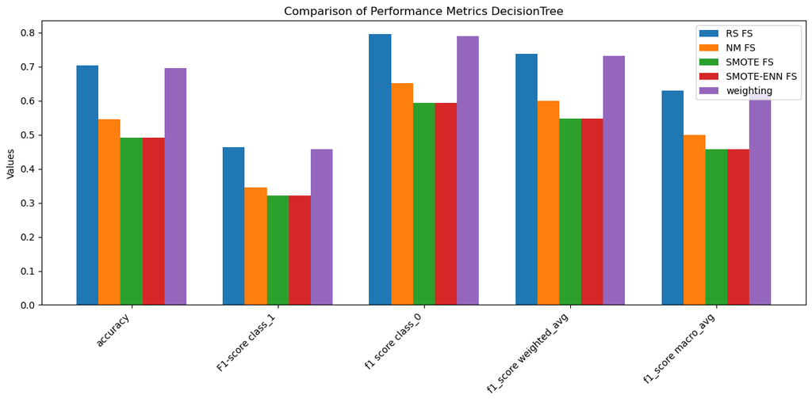

```python
import matplotlib.pyplot as plt

data = {'RS FS': {'accuracy': 0.7038536022803925,
  'F1-score class_1': 0.46328574808738865,
  'f1 score class_0': 0.7955105475088646,
  'f1_score weighted_avg': 0.7388276776030005,
  'f1_score macro_avg': 0.6293981477981266},
 'NM FS': {'accuracy': 0.5452488195487086,
  'F1-score class_1': 0.34590466652060964,
  'f1 score class_0': 0.6514684055167352,
  'f1_score weighted_avg': 0.5993343393795065,
  'f1_score macro_avg': 0.4986865360186724},
 'SMOTE FS': {'accuracy': 0.492155710773114,
  'F1-score class_1': 0.3221909214997241,
  'f1 score class_0': 0.5939701814512621,
  'f1_score weighted_avg': 0.5476002883494494,
  'f1_score macro_avg': 0.4580805514754931},
 'SMOTE-ENN FS': {'accuracy': 0.492155710773114,
  'F1-score class_1': 0.3221909214997241,
  'f1 score class_0': 0.5939701814512621,
  'f1_score weighted_avg': 0.5476002883494494,
  'f1_score macro_avg': 0.4580805514754931},
 'weighting': {'accuracy': 0.6963901037926757,
  'F1-score class_1': 0.45714508034081625,
  'f1 score class_0': 0.7892646237030101,
  'f1_score weighted_avg': 0.7325997121660742,
  'f1_score macro_avg': 0.6232048520219131}}

categories = list(data['RS FS'].keys())
num_models = len(data)
width = 0.15
positions = list(range(len(categories)))

plt.figure(figsize=(12, 6))

for i, (model, values) in enumerate(data.items()):
    values = [values.get(key, 0) for key in categories]
    plt.bar([pos + width * i for pos in positions], values, width, label=model)

#plt.xlabel('Metrics')
plt.ylabel('Values')
plt.title('Comparison of Performance Metrics DecisionTree')
plt.xticks([pos + width * 2 for pos in positions], categories, rotation=45, ha='right')
plt.legend()
plt.tight_layout()
plt.show()
```

### choosing the best DecisionTree model

Random down-Sampling with feature selection (10 features)

DecisionTreeClassifier(criterion='entropy', max_depth=7, min_samples_leaf=2)

```python
dt = DecisionTreeClassifier(criterion='entropy', max_depth=7, min_samples_leaf=2)
dt.fit(X_train , Y_train)
```

```
DecisionTreeClassifier(criterion='entropy', max_depth=7, min_samples_leaf=2)
```

```python
# make predictions on test set

y_pred=dt.predict(X_test)
dt_predictions = y_pred

print('Training set score: {:.4f}'.format(dt.score(X_train, Y_train)))

print('Test set score: {:.4f}'.format(dt.score(X_test, Y_test)))
```

```
Training set score: 0.7267
Test set score: 0.6936
```

```python
#check MSE & RMSE

mse =mean_squared_error(Y_test, y_pred)
print('Mean Squared Error : '+ str(mse))
rmse = math.sqrt(mean_squared_error(Y_test, y_pred))
print('Root Mean Squared Error : '+ str(rmse))
```

```
Mean Squared Error : 0.3064386274125813
Root Mean Squared Error : 0.5535689906530001
```

```python
matrix = classification_report(Y_test,y_pred )
print(matrix)
```

```
              precision    recall  f1-score   support

           0       0.93      0.68      0.79     38116
           1       0.33      0.76      0.46      7841

    accuracy                           0.69     45957
   macro avg       0.63      0.72      0.62     45957
weighted avg       0.83      0.69      0.73     45957
```

[figure not shown]

```python
# calculating and plotting the confusion matrix
cm1 = confusion_matrix(Y_test,y_pred)
plot_confusion_matrix(conf_mat=cm1,show_absolute=True,
                                show_normed=True,
                                colorbar=True)
plt.show()
```

# Model 3: KNN

testing this model to find best k with balanced data and feature selection (3 columns)

```python
knn_info_dic = {}
for i in tqdm(range(1, 101)):
#for i in range(1,505):
#for N in Neighbors:
    knn = KNeighborsClassifier(n_neighbors = i)
    knn.fit(X_train, Y_train)
    y_pred = knn.predict(X_test)
    acc = accuracy_score(Y_test, y_pred)
    f1_score_class_1 = f1_score(Y_test, y_pred, pos_label=1)
    f1_score_class_0 = f1_score(Y_test, y_pred, pos_label=0)
    f1_score_weighted_avg = f1_score(Y_test, y_pred, average='weighted')
    f1_score_macro_avg = f1_score(Y_test, y_pred, average='macro')
    knn_info_dic[i] = {'accuracy': acc, 'F1-score class_1': f1_score_class_1 ,'f1 score class_0' : f1_score_class_0, 'f1_score weighted_avg' : f1_score_weighted_avg ,'f1_score macro_avg':f1_score_macro_avg}
```

#### saving knn-info-dic

```python
knn_info_v3 = pd.DataFrame.from_dict(knn_info_dic, orient='index')
csv_filename = "knn_info_v3.csv"
knn_info_v3.to_csv(csv_filename, index=False)
```

If you do not want to re-run and find the model parameter, by uncommenting the following cell and running it, you can observe the results and scores of the KNN model for different parameters. First, download the 'knn_info.csv' file and place it in the directory of this notebook.

```python
'''
knn_info = pd.read_csv('knn_info.csv')
knn_info_dic = knn_info.to_dict(orient='index')
'''
```

#### Finding the value of k for maximum scores.

```python
# accuracy
max_acc_key = max(knn_info_dic, key=lambda k: knn_info_dic[k]['accuracy'])
print("Key with the highest F1-score:", max_acc_key)
print("Information for the key:", knn_info_dic[max_acc_key])
```

```
Key with the highest F1-score: 2
Information for the key: {'accuracy': 0.6850099005592184, 'F1-score class_1': 0.41591349257585536, 'f1 score class_0': 0.7843587069864443, 'f1_score weighted_avg': 0.7214960543721868, 'f1_score macro_avg': 0.6001360997811498}
```

```python
# F1_score weighted avg
max_f1avg_key = max(knn_info_dic, key=lambda k: knn_info_dic[k]['f1_score weighted_avg'])
print("Key with the highest F1-score:", max_f1avg_key)
print("Information for the key:", knn_info_dic[max_f1avg_key])
```

```
Key with the highest F1-score: 2
Information for the key: {'accuracy': 0.6850099005592184, 'F1-score class_1': 0.41591349257585536, 'f1 score class_0': 0.7843587069864443, 'f1_score weighted_avg': 0.7214960543721868, 'f1_score macro_avg': 0.6001360997811498}
```

#### Displaying the changes in accuracy and F1 score of the model for parameter variations.

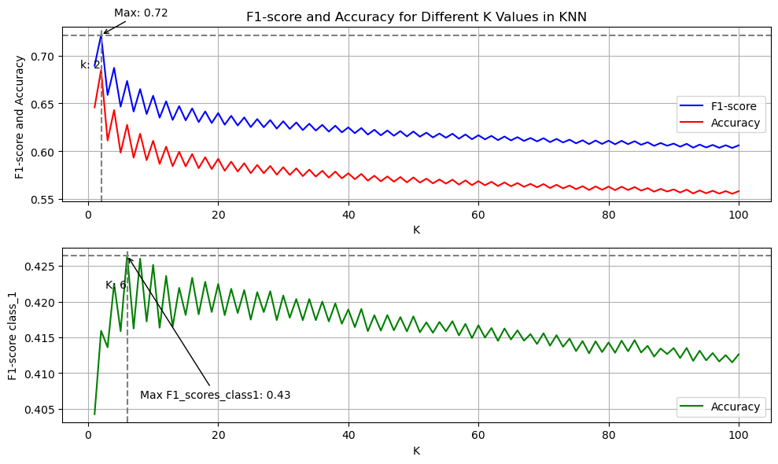

```python
import matplotlib.pyplot as plt


i_values = list(knn_info_dic.keys())
f1_scores = [entry['f1_score weighted_avg'] for entry in knn_info_dic.values()]
accuracies = [entry['accuracy'] for entry in knn_info_dic.values()]
f1_scores_class1 = [entry['F1-score class_1'] for entry in knn_info_dic.values()]

plt.figure(figsize=(10, 6))

plt.subplot(2, 1, 1)
plt.plot(i_values, f1_scores, color='blue', label='F1-score')
plt.plot(i_values, accuracies, color='red', label='Accuracy')
plt.xlabel('K')
plt.ylabel('F1-score and Accuracy ')
plt.title('F1-score and Accuracy for Different K Values in KNN')
plt.grid(True)
plt.legend()


plt.subplot(2, 1, 2)
plt.plot(i_values, f1_scores_class1, color='green', label='Accuracy')
plt.xlabel('K')
plt.ylabel('F1-score class_1')
plt.grid(True)
plt.legend()


max_f1_score = max(f1_scores)
max_f1_score_index = f1_scores.index(max_f1_score)
max_f1_score_i = i_values[max_f1_score_index]


max_accuracy = max(accuracies)
max_accuracy_index = accuracies.index(max_accuracy)
max_accuracy_i = i_values[max_accuracy_index]

max_f1_scores_class1 = max(f1_scores_class1)
max_f1_scores_class1_index = f1_scores_class1.index(max_f1_scores_class1)
max_f1_scores_class1_i = i_values[max_f1_scores_class1_index]


plt.subplot(2, 1, 1)
plt.axvline(x=max_f1_score_i, color='gray', linestyle='--')
plt.axhline(y=max_f1_score, color='gray', linestyle='--')
plt.annotate(f'Max: {max_f1_score:.2f}', xy=(max_f1_score_i, max_f1_score),
             xytext=(max_f1_score_i + 2, max_f1_score + 0.02),
             arrowprops=dict(facecolor='black', arrowstyle='->'))
plt.annotate(f'k: {max_f1_score_i}', xy=(max_f1_score_i, max_f1_score), xytext=(-10, -30),
             textcoords='offset points', color='black', ha='center')


plt.subplot(2, 1, 2)
plt.axvline(x=max_f1_scores_class1_i, color='gray', linestyle='--')
plt.axhline(y=max_f1_scores_class1, color='gray', linestyle='--')
plt.annotate(f'Max F1_scores_class1: {max_f1_scores_class1:.2f}', xy=(max_f1_scores_class1_i, max_f1_scores_class1),
             xytext=(max_f1_scores_class1_i + 2, max_f1_scores_class1 - 0.02),
             arrowprops=dict(facecolor='black', arrowstyle='->'))
plt.annotate(f'K: {max_f1_scores_class1_i}', xy=(max_f1_scores_class1_i, max_f1_scores_class1), xytext=(-10, -30),
             textcoords='offset points', color='black', ha='center')

plt.tight_layout()
plt.show()
```

#### choosing best K

```python
k = 2
```

```python
knn_results = {}
```

### KNN: K = 2 with 17 features SMOTE-ENN (17 feature)

```python
knn = KNeighborsClassifier(n_neighbors = k)
knn.fit(X_train, Y_train)
y_pred = knn.predict(X_test)
acc = accuracy_score(Y_test, y_pred)
f1_score_class_1 = f1_score(Y_test, y_pred, pos_label=1)
f1_score_class_0 = f1_score(Y_test, y_pred, pos_label=0)
f1_score_weighted_avg = f1_score(Y_test, y_pred, average='weighted')
f1_score_macro_avg = f1_score(Y_test, y_pred, average='macro')
knn_results['17 feature'] = {'accuracy': acc, 'F1-score class_1': f1_score_class_1 ,'f1 score class_0' : f1_score_class_0, 'f1_score weighted_avg' : f1_score_weighted_avg ,'f1_score macro_avg':f1_score_macro_avg}
```

### KNN: K = 2 with 17 features Random sampling (17F RS)

```python
knn = KNeighborsClassifier(n_neighbors = k)
knn.fit(X_train, Y_train)
y_pred = knn.predict(X_test)
acc = accuracy_score(Y_test, y_pred)
f1_score_class_1 = f1_score(Y_test, y_pred, pos_label=1)
f1_score_class_0 = f1_score(Y_test, y_pred, pos_label=0)
f1_score_weighted_avg = f1_score(Y_test, y_pred, average='weighted')
f1_score_macro_avg = f1_score(Y_test, y_pred, average='macro')
knn_results['17F RS'] = {'accuracy': acc, 'F1-score class_1': f1_score_class_1 ,'f1 score class_0' : f1_score_class_0, 'f1_score weighted_avg' : f1_score_weighted_avg ,'f1_score macro_avg':f1_score_macro_avg}
```

### KNN: K = 2 with 14 features SMOTE-ENN

```python
knn = KNeighborsClassifier(n_neighbors = k)
knn.fit(X_train, Y_train)
y_pred = knn.predict(X_test)
acc = accuracy_score(Y_test, y_pred)
f1_score_class_1 = f1_score(Y_test, y_pred, pos_label=1)
f1_score_class_0 = f1_score(Y_test, y_pred, pos_label=0)
f1_score_weighted_avg = f1_score(Y_test, y_pred, average='weighted')
f1_score_macro_avg = f1_score(Y_test, y_pred, average='macro')
knn_results['14 feature'] = {'accuracy': acc, 'F1-score class_1': f1_score_class_1 ,'f1 score class_0' : f1_score_class_0, 'f1_score weighted_avg' : f1_score_weighted_avg ,'f1_score macro_avg':f1_score_macro_avg}
```

### KNN: K = 2 with 17 features SMOTE (17F SMOTE)

```python
knn = KNeighborsClassifier(n_neighbors = k)
knn.fit(X_train, Y_train)
y_pred = knn.predict(X_test)
acc = accuracy_score(Y_test, y_pred)
f1_score_class_1 = f1_score(Y_test, y_pred, pos_label=1)
f1_score_class_0 = f1_score(Y_test, y_pred, pos_label=0)
f1_score_weighted_avg = f1_score(Y_test, y_pred, average='weighted')
f1_score_macro_avg = f1_score(Y_test, y_pred, average='macro')
knn_results['17F SMOTE'] = {'accuracy': acc, 'F1-score class_1': f1_score_class_1 ,'f1 score class_0' : f1_score_class_0, 'f1_score weighted_avg' : f1_score_weighted_avg ,'f1_score macro_avg':f1_score_macro_avg}
```

### KNN: K = 2 without feature selection

```python
knn = KNeighborsClassifier(n_neighbors = k)
knn.fit(X_train, Y_train)
y_pred = knn.predict(X_test)
acc = accuracy_score(Y_test, y_pred)
f1_score_class_1 = f1_score(Y_test, y_pred, pos_label=1)
f1_score_class_0 = f1_score(Y_test, y_pred, pos_label=0)
f1_score_weighted_avg = f1_score(Y_test, y_pred, average='weighted')
f1_score_macro_avg = f1_score(Y_test, y_pred, average='macro')
knn_results['without FS'] = {'accuracy': acc, 'F1-score class_1': f1_score_class_1 ,'f1 score class_0' : f1_score_class_0, 'f1_score weighted_avg' : f1_score_weighted_avg ,'f1_score macro_avg':f1_score_macro_avg}
```

```python
knn_results
```

```
{'without FS': {'accuracy': 0.6738908109754771,
  'F1-score class_1': 0.40909986988920866,
  'f1 score class_0': 0.7748042854352302,
  'f1_score weighted_avg': 0.7124092569891533,
  'f1_score macro_avg': 0.5919520776622194},
 '17 feature': {'accuracy': 0.6774593641882629,
  'F1-score class_1': 0.40833433121781826,
  'f1 score class_0': 0.7783012518508547,
  'f1_score weighted_avg': 0.7151789717915898,
  'f1_score macro_avg': 0.5933177915343365},
 '14 feature': {'accuracy': 0.6828121940074418,
  'F1-score class_1': 0.4116721152681923,
  'f1 score class_0': 0.7828768041467448,
  'f1_score weighted_avg': 0.7195433410073594,
  'f1_score macro_avg': 0.5972744597074685},
 '17F RS': {'accuracy': 0.7838849359183585,
  'F1-score class_1': 0.3336911310881524,
  'f1 score class_0': 0.8710263868688968,
  'f1_score weighted_avg': 0.7793483891628495,
  'f1_score macro_avg': 0.6023587589785246},
 '17F SMOTE': {'accuracy': 0.7444567748112366,
  'F1-score class_1': 0.3346929526399275,
  'f1 score class_0': 0.8418572082626377,
  'f1_score weighted_avg': 0.755326866239928,
  'f1_score macro_avg': 0.5882750804512826}}
```

#### saving knn-results

```python
'''
knn_results_df = pd.DataFrame.from_dict(knn_results, orient='index')
csv_filename = "knn_results.csv"
knn_results_df.to_csv(csv_filename, index=False)
'''
```

```
'\nknn_results_df = pd.DataFrame.from_dict(knn_results, orient=\'index\')\ncsv_filename = "knn_results.csv"\nknn_results_df.to_csv(csv_filename, index=False)\n'
```

If you do not want to re-run and find the model parameter, by uncommenting the following cell and running it, you can observe the results and scores of the KNN model for different parameters. First, download the 'knn_results.csv' file and place it in the directory of this notebook.

```python
'''
knn_results_df = pd.read_csv('knn_results.csv')
knn_results = knn_results_df.to_dict(orient='index')
'''
```

#### Displaying the changes in accuracy and F1 score of the model

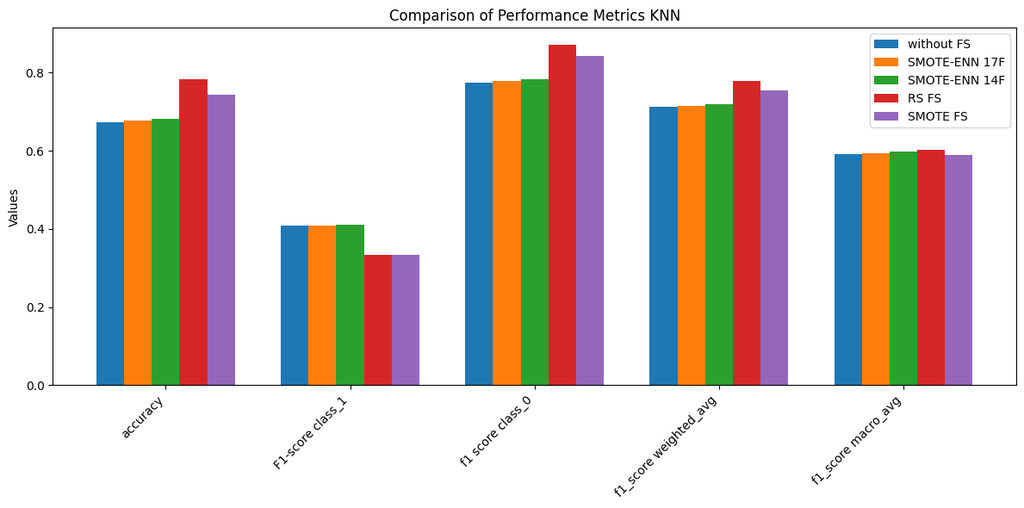

```python
import matplotlib.pyplot as plt

data = {
    'without FS': {'accuracy': 0.6738908109754771,
                    'F1-score class_1': 0.40909986988920866,
                    'f1 score class_0': 0.7748042854352302,
                    'f1_score weighted_avg': 0.7124092569891533,
                    'f1_score macro_avg': 0.5919520776622194},
    'SMOTE-ENN 17F': {'accuracy': 0.6774593641882629,
                   'F1-score class_1': 0.40833433121781826,
                   'f1 score class_0': 0.7783012518508547,
                   'f1_score weighted_avg': 0.7151789717915898,
                   'f1_score macro_avg': 0.5933177915343365},
    'SMOTE-ENN 14F': {'accuracy': 0.6828121940074418,
                   'F1-score class_1': 0.4116721152681923,
                   'f1 score class_0': 0.7828768041467448,
                   'f1_score weighted_avg': 0.7195433410073594,
                   'f1_score macro_avg': 0.5972744597074685},
    'RS FS': {'accuracy': 0.7838849359183585,
               'F1-score class_1': 0.3336911310881524,
               'f1 score class_0': 0.8710263868688968,
               'f1_score weighted_avg': 0.7793483891628495,
               'f1_score macro_avg': 0.6023587589785246},
    'SMOTE FS': {'accuracy': 0.7444567748112366,
                  'F1-score class_1': 0.3346929526399275,
                  'f1 score class_0': 0.8418572082626377,
                  'f1_score weighted_avg': 0.755326866239928,
                  'f1_score macro_avg': 0.5882750804512826}
}

categories = list(data['without FS'].keys())
num_models = len(data)
width = 0.15
positions = list(range(len(categories)))

plt.figure(figsize=(12, 6))

for i, (model, values) in enumerate(data.items()):
    values = [values.get(key, 0) for key in categories]
    plt.bar([pos + width * i for pos in positions], values, width, label=model)

#plt.xlabel('Metrics')
plt.ylabel('Values')
plt.title('Comparison of Performance Metrics KNN')
plt.xticks([pos + width * 2 for pos in positions], categories, rotation=45, ha='right')
plt.legend()
plt.tight_layout()
plt.show()
```

### choosing the best KNN model

KNN with k = 2 , 17 features and random sampling method for balancing data

```python
knn = KNeighborsClassifier(n_neighbors = k)
knn.fit(X_train, Y_train)
y_pred = knn.predict(X_test)
knn_predictions = y_pred
acc_knn = accuracy_score(Y_test, y_pred)
print("Best KNN accuracy is: ", acc_knn)
print('Training set score: {:.4f}'.format(knn.score(X_train, Y_train)))

print('Test set score: {:.4f}'.format(knn.score(X_test, Y_test)))
```

```
Best KNN accuracy is:  0.7863872750614705
Training set score: 0.7493
Test set score: 0.7864
```

```python
#check MSE & RMSE
import math
mse =mean_squared_error(Y_test, y_pred)
print('Mean Squared Error : '+ str(mse))
rmse = math.sqrt(mean_squared_error(Y_test, y_pred))
print('Root Mean Squared Error : '+ str(rmse))
```

```
Mean Squared Error : 0.2136127249385295
Root Mean Squared Error : 0.4621825666752582
```

```python
from sklearn.metrics import classification_report
matrix = classification_report(Y_test,y_pred )
print(matrix)
```

```
              precision    recall  f1-score   support

           0       0.86      0.88      0.87     38116
           1       0.36      0.32      0.34      7841

    accuracy                           0.79     45957
   macro avg       0.61      0.60      0.60     45957
weighted avg       0.78      0.79      0.78     45957
```

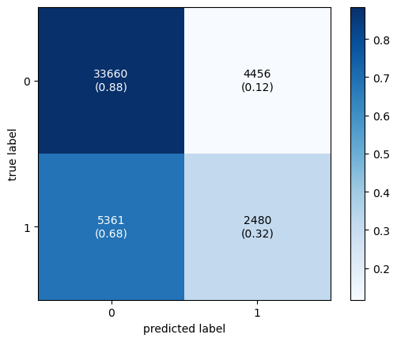

```python
# calculating and plotting the confusion matrix
from mlxtend.plotting import plot_confusion_matrix
cm1 = confusion_matrix(Y_test,y_pred)
plot_confusion_matrix(conf_mat=cm1,show_absolute=True,
                                show_normed=True,
                                colorbar=True)
plt.show()
```

# Model 4: Random Forest

Using Weighting Method for Data Balancing

```python
rf_results = {}
```

```python
rf = RandomForestClassifier(max_depth = 12, n_estimators =10, random_state=42, class_weight= dict({0:0.6, 1:2.8}) )
rf.fit(X_train, Y_train)
# make predictions on test set
y_pred=rf.predict(X_test)
rf_predictions = y_pred
# Calculate the accuracy of the model
acc = accuracy_score(Y_test, y_pred)
f1_score_class_1 = f1_score(Y_test, y_pred, pos_label=1)
f1_score_class_0 = f1_score(Y_test, y_pred, pos_label=0)
f1_score_weighted_avg = f1_score(Y_test, y_pred, average='weighted')
f1_score_macro_avg = f1_score(Y_test, y_pred, average='macro')
rf_results['weighting'] = {'accuracy': acc, 'F1-score class_1': f1_score_class_1 ,'f1 score class_0' : f1_score_class_0, 'f1_score weighted_avg' : f1_score_weighted_avg ,'f1_score macro_avg':f1_score_macro_avg}
print("Accuracy:" , acc)
print('Training set score: {:.4f}'.format(rf.score(X_train, Y_train)))
print('Test set score: {:.4f}'.format(rf.score(X_test, Y_test)))
```

```
Accuracy: 0.7332288878734469
Training set score: 0.7502
Test set score: 0.7332
```

```python
rf_results
```

```
{'weighting': {'accuracy': 0.7332288878734469,
  'F1-score class_1': 0.4757995553275184,
  'f1 score class_0': 0.821089805329364,
  'f1_score weighted_avg': 0.7621777603685426,
  'f1_score macro_avg': 0.6484446803284412}}
```

```python
#check MSE & RMSE
mse =mean_squared_error(Y_test, y_pred)
print('Mean Squared Error : '+ str(mse))
rmse = math.sqrt(mean_squared_error(Y_test, y_pred))
print('Root Mean Squared Error : '+ str(rmse))
```

```
Mean Squared Error : 0.2667711121265531
Root Mean Squared Error : 0.5164988984756435
```

```python
matrix = classification_report(Y_test,y_pred )
print(matrix)
```

```
              precision    recall  f1-score   support

           0       0.93      0.74      0.82     38116
           1       0.36      0.71      0.48      7841

    accuracy                           0.73     45957
   macro avg       0.64      0.72      0.65     45957
weighted avg       0.83      0.73      0.76     45957
```

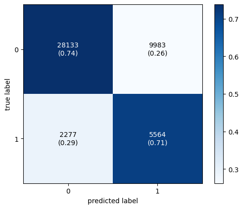

```python
# calculating and plotting the confusion matrix
cm1 = confusion_matrix(Y_test,y_pred)
plot_confusion_matrix(conf_mat=cm1,show_absolute=True,
                                show_normed=True,
                                colorbar=True)
plt.show()
```

```python
# saving results
'''
rf_results_df = pd.DataFrame.from_dict(rf_results, orient='index')
csv_filename = "rf_results.csv"
rf_results_df.to_csv(csv_filename, index=False)
'''
```

```
'\nrf_results_df = pd.DataFrame.from_dict(rf_results, orient=\'index\')\ncsv_filename = "rf_results.csv"\nrf_results_df.to_csv(csv_filename, index=False)\n'
```

# Model 5: SVM

The optimization of this model's parameters has been performed using the data balancing technique along with the grid search method.

```python
#svm_results = {}
```

```python
from sklearn.svm import SVC
from sklearn.svm import LinearSVC
```

### Random down-Sampling with feature selection (10 features)

LinearSVC(C=10.0, dual=False, penalty='l1')

```python
svc = LinearSVC(C=10.0, dual=False, penalty='l1')
svc.fit(X_train , Y_train)

# make predictions on test set
y_pred=svc.predict(X_test)
acc = accuracy_score(Y_test, y_pred)
f1_score_class_1 = f1_score(Y_test, y_pred, pos_label=1)
f1_score_class_0 = f1_score(Y_test, y_pred, pos_label=0)
f1_score_weighted_avg = f1_score(Y_test, y_pred, average='weighted')
f1_score_macro_avg = f1_score(Y_test, y_pred, average='macro')
svm_results['RS FS'] = {'accuracy': acc, 'F1-score class_1': f1_score_class_1 ,'f1 score class_0' : f1_score_class_0, 'f1_score weighted_avg' : f1_score_weighted_avg ,'f1_score macro_avg':f1_score_macro_avg}
print("accuracy is: ", acc)
print('Training set score: {:.4f}'.format(svc.score(X_train, Y_train)))
print('Test set score: {:.4f}'.format(svc.score(X_test, Y_test)))
```

```
accuracy is:  0.7152773244554692
Training set score: 0.7259
Test set score: 0.7153
```

The results of this model do not show a noticeable change without removing 10 features.

### NearMiss algorithm with feature selection (10 features)

LinearSVC(loss='hinge')

```python
svc = LinearSVC(loss='hinge')
svc.fit(X_train , Y_train)

# make predictions on test set
y_pred=svc.predict(X_test)
acc = accuracy_score(Y_test, y_pred)
f1_score_class_1 = f1_score(Y_test, y_pred, pos_label=1)
f1_score_class_0 = f1_score(Y_test, y_pred, pos_label=0)
f1_score_weighted_avg = f1_score(Y_test, y_pred, average='weighted')
f1_score_macro_avg = f1_score(Y_test, y_pred, average='macro')
svm_results['NM FS'] = {'accuracy': acc, 'F1-score class_1': f1_score_class_1 ,'f1 score class_0' : f1_score_class_0, 'f1_score weighted_avg' : f1_score_weighted_avg ,'f1_score macro_avg':f1_score_macro_avg}
print("accuracy is: ", acc)
print('Training set score: {:.4f}'.format(svc.score(X_train, Y_train)))
print('Test set score: {:.4f}'.format(svc.score(X_test, Y_test)))
```

```
accuracy is:  0.6479317622995409
Training set score: 0.7972
Test set score: 0.6479
```

The results of this model do not show a noticeable change without removing 10 features. LinearSVC(C=10.0, loss='hinge')

### SMOTE algorithm with feature selection (14 features)

LinearSVC(C=10.0)

```python
svc = LinearSVC(C=10.0)
svc.fit(X_train , Y_train)

# make predictions on test set
y_pred=svc.predict(X_test)
acc = accuracy_score(Y_test, y_pred)
f1_score_class_1 = f1_score(Y_test, y_pred, pos_label=1)
f1_score_class_0 = f1_score(Y_test, y_pred, pos_label=0)
f1_score_weighted_avg = f1_score(Y_test, y_pred, average='weighted')
f1_score_macro_avg = f1_score(Y_test, y_pred, average='macro')
svm_results['SMOTE FS'] = {'accuracy': acc, 'F1-score class_1': f1_score_class_1 ,'f1 score class_0' : f1_score_class_0, 'f1_score weighted_avg' : f1_score_weighted_avg ,'f1_score macro_avg':f1_score_macro_avg}
print("accuracy is: ", acc)
print('Training set score: {:.4f}'.format(svc.score(X_train, Y_train)))
print('Test set score: {:.4f}'.format(svc.score(X_test, Y_test)))
```

```
accuracy is:  0.5994951802772157
Training set score: 0.7905
Test set score: 0.5995
```

The results of this model show improvement when compared to not removing the 14 features.

LinearSVC(C=10.0, loss='hinge')

### SMOTE-ENN algorithm with feature selection (17 features)

LinearSVC(C=0.1, loss='hinge')

```python
svc = LinearSVC(C=0.1, loss='hinge')
svc.fit(X_train , Y_train)

# make predictions on test set
y_pred=svc.predict(X_test)
acc = accuracy_score(Y_test, y_pred)
f1_score_class_1 = f1_score(Y_test, y_pred, pos_label=1)
f1_score_class_0 = f1_score(Y_test, y_pred, pos_label=0)
f1_score_weighted_avg = f1_score(Y_test, y_pred, average='weighted')
f1_score_macro_avg = f1_score(Y_test, y_pred, average='macro')
svm_results['SMOTE-ENN FS'] = {'accuracy': acc, 'F1-score class_1': f1_score_class_1 ,'f1 score class_0' : f1_score_class_0, 'f1_score weighted_avg' : f1_score_weighted_avg ,'f1_score macro_avg':f1_score_macro_avg}
print("accuracy is: ", acc)
print('Training set score: {:.4f}'.format(svc.score(X_train, Y_train)))
print('Test set score: {:.4f}'.format(svc.score(X_test, Y_test)))
```

```
accuracy is:  0.4985747546619666
Training set score: 0.8420
Test set score: 0.4986
```

### SVM: with weighting

```python
from sklearn import svm
clf= svm.SVC(kernel='rbf', C= 1.0, class_weight= dict({0:0.6, 1:2.8}))
# train the model
clf.fit(X_train, Y_train)
y_pred=clf.predict(X_test)
svm_predictions = y_pred
acc = accuracy_score(Y_test, y_pred)
f1_score_class_1 = f1_score(Y_test, y_pred, pos_label=1)
f1_score_class_0 = f1_score(Y_test, y_pred, pos_label=0)
f1_score_weighted_avg = f1_score(Y_test, y_pred, average='weighted')
f1_score_macro_avg = f1_score(Y_test, y_pred, average='macro')
svm_results['weighting'] = {'accuracy': acc, 'F1-score class_1': f1_score_class_1 ,'f1 score class_0' : f1_score_class_0, 'f1_score weighted_avg' : f1_score_weighted_avg ,'f1_score macro_avg':f1_score_macro_avg}
print("accuracy is: ", acc)
print('Training set score: {:.4f}'.format(clf.score(X_train, Y_train)))
print('Test set score: {:.4f}'.format(clf.score(X_test, Y_test)))
```

```
accuracy is:  0.7034184128641991
Training set score: 0.7013
Test set score: 0.7034
```

```python
svm_results
```

```
{'RS FS': {'accuracy': 0.7152773244554692,
  'F1-score class_1': 0.47201710850179557,
  'f1 score class_0': 0.8050825996931373,
  'f1_score weighted_avg': 0.7482562943113389,
  'f1_score macro_avg': 0.6385498540974665},
 'NM FS': {'accuracy': 0.6479317622995409,
  'F1-score class_1': 0.3707218419415059,
  'f1 score class_0': 0.7555965076583789,
  'f1_score weighted_avg': 0.6899307276055905,
  'f1_score macro_avg': 0.5631591747999425},
 'SMOTE FS': {'accuracy': 0.5994951802772157,
  'F1-score class_1': 0.3320510959500654,
  'f1 score class_0': 0.7140060287765314,
  'f1_score weighted_avg': 0.6488384019015762,
  'f1_score macro_avg': 0.5230285623632984},
 'SMOTE-ENN FS': {'accuracy': 0.4985747546619666,
  'F1-score class_1': 0.3372828712757391,
  'f1 score class_0': 0.5967239508592629,
  'f1_score weighted_avg': 0.5524591488701337,
  'f1_score macro_avg': 0.467003411067501},
 'weighting': {'accuracy': 0.7034184128641991,
  'F1-score class_1': 0.4719510305284364,
  'f1 score class_0': 0.7938035157786452,
  'f1_score weighted_avg': 0.7388903287375658,
  'f1_score macro_avg': 0.6328772731535408}}
```

#### saving svm-results

```python
'''
svm_results_df = pd.DataFrame.from_dict(svm_results, orient='index')
csv_filename = "svm_results.csv"
svm_results_df.to_csv(csv_filename, index=False)
'''
```

If you do not want to re-run and find the model parameter, by uncommenting the following cell and running it, you can observe the results and scores of the model for different parameters. First, download the 'svm_results.csv' file and place it in the directory of this notebook.

```python
'''
svm_results_df = pd.read_csv('svm_results.csv')
svm_results = svm_results_df.to_dict(orient='index')
'''
```

#### Displaying the changes in accuracy and F1 score of the model

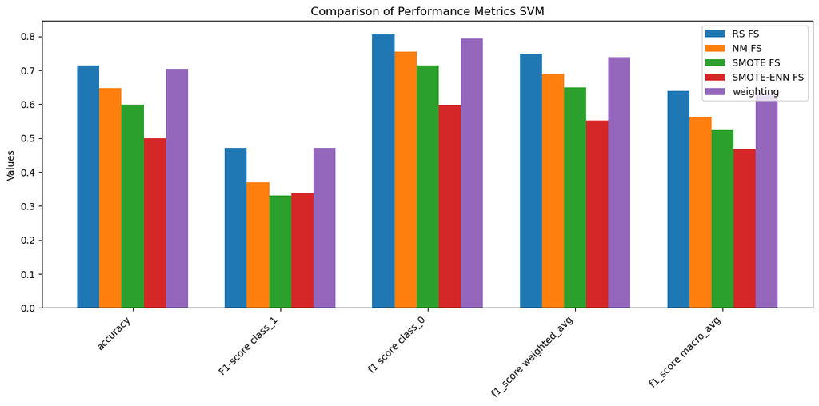

```python
import matplotlib.pyplot as plt

data = {'RS FS': {'accuracy': 0.7152773244554692,
  'F1-score class_1': 0.47201710850179557,
  'f1 score class_0': 0.8050825996931373,
  'f1_score weighted_avg': 0.7482562943113389,
  'f1_score macro_avg': 0.6385498540974665},
 'NM FS': {'accuracy': 0.6479317622995409,
  'F1-score class_1': 0.3707218419415059,
  'f1 score class_0': 0.7555965076583789,
  'f1_score weighted_avg': 0.6899307276055905,
  'f1_score macro_avg': 0.5631591747999425},
 'SMOTE FS': {'accuracy': 0.5994951802772157,
  'F1-score class_1': 0.3320510959500654,
  'f1 score class_0': 0.7140060287765314,
  'f1_score weighted_avg': 0.6488384019015762,
  'f1_score macro_avg': 0.5230285623632984},
 'SMOTE-ENN FS': {'accuracy': 0.4985747546619666,
  'F1-score class_1': 0.3372828712757391,
  'f1 score class_0': 0.5967239508592629,
  'f1_score weighted_avg': 0.5524591488701337,
  'f1_score macro_avg': 0.467003411067501},
 'weighting': {'accuracy': 0.7034184128641991,
  'F1-score class_1': 0.4719510305284364,
  'f1 score class_0': 0.7938035157786452,
  'f1_score weighted_avg': 0.7388903287375658,
  'f1_score macro_avg': 0.6328772731535408}}

categories = list(data['RS FS'].keys())
num_models = len(data)
width = 0.15
positions = list(range(len(categories)))

plt.figure(figsize=(12, 6))

for i, (model, values) in enumerate(data.items()):
    values = [values.get(key, 0) for key in categories]
    plt.bar([pos + width * i for pos in positions], values, width, label=model)

#plt.xlabel('Metrics')
plt.ylabel('Values')
plt.title('Comparison of Performance Metrics SVM')
plt.xticks([pos + width * 2 for pos in positions], categories, rotation=45, ha='right')
plt.legend()
plt.tight_layout()
plt.show()
```

### choosing the best SVM model

Random down-Sampling with feature selection (10 features) LinearSVC(C=10.0, dual=False, penalty='l1')

```python
svc = LinearSVC(C=10.0, dual=False, penalty='l1')
svc.fit(X_train , Y_train)

# make predictions on test set
y_pred=svc.predict(X_test)
svm_predictions = y_pred
print('Training set score: {:.4f}'.format(svc.score(X_train, Y_train)))
print('Test set score: {:.4f}'.format(svc.score(X_test, Y_test)))
```

```
Training set score: 0.7231
Test set score: 0.7162
```

```python
#check MSE & RMSE
mse =mean_squared_error(Y_test, y_pred)
print('Mean Squared Error : '+ str(mse))
rmse = math.sqrt(mean_squared_error(Y_test, y_pred))
print('Root Mean Squared Error : '+ str(rmse))
```

```
Mean Squared Error : 0.2837652588289053
Root Mean Squared Error : 0.5326962162704981
```

```python
matrix = classification_report(Y_test,y_pred )
print(matrix)
```

```
              precision    recall  f1-score   support

           0       0.93      0.71      0.81     38116
           1       0.35      0.75      0.47      7841

    accuracy                           0.72     45957
   macro avg       0.64      0.73      0.64     45957
weighted avg       0.83      0.72      0.75     45957
```

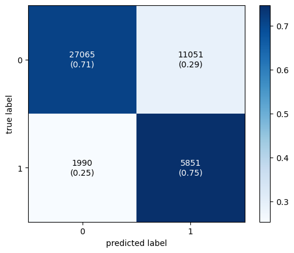

```python
# calculating and plotting the confusion matrix
cm1 = confusion_matrix(Y_test,y_pred)
plot_confusion_matrix(conf_mat=cm1,show_absolute=True,
                                show_normed=True,
                                colorbar=True)
plt.show()
```

# Model 6: XGBoost

Using Weighting Method for Data Balancing

```python
#xgb_result = {}
```

```python
import xgboost as xgb
from xgboost import XGBClassifier
a=0
# Set class weights
class_weights = dict({0:0.6, 1:2.8}) # Class 0: 1, Class 1: 10
# Set "scale_pos_weight" based on class balance
pos_weight = sum(class_weights.values()) / sum(class_weights.keys())
# Train XGBoost model
model = xgb.XGBClassifier(scale_pos_weight=pos_weight) #,
class_weight=class_weights
model.fit(X_train, Y_train)
y_pred=model.predict(X_test)
xgb_predictions = y_pred
# Calculate the accuracy of the model
acc = accuracy_score(Y_test, y_pred)
f1_score_class_1 = f1_score(Y_test, y_pred, pos_label=1)
f1_score_class_0 = f1_score(Y_test, y_pred, pos_label=0)
f1_score_weighted_avg = f1_score(Y_test, y_pred, average='weighted')
f1_score_macro_avg = f1_score(Y_test, y_pred, average='macro')
xgb_result['weighting'] = {'accuracy': acc, 'F1-score class_1': f1_score_class_1 ,'f1 score class_0' : f1_score_class_0, 'f1_score weighted_avg' : f1_score_weighted_avg ,'f1_score macro_avg':f1_score_macro_avg}
print("Accuracy:" , acc)
```

```
Accuracy: 0.7624083382292143
```

#### saving xgb-results

```python
xgb_result
```

```
{'weighting': {'accuracy': 0.7624083382292143,
  'F1-score class_1': 0.4847340852248597,
  'f1 score class_0': 0.8456089249607623,
  'f1_score weighted_avg': 0.7840378994723881,
  'f1_score macro_avg': 0.6651715050928111}}
```

```python
'''
xgb_results_df = pd.DataFrame.from_dict(xgb_result, orient='index')
csv_filename = "xgb_results.csv"
xgb_results_df.to_csv(csv_filename, index=False)
'''
```

```python
'''
xgb_results_df = pd.read_csv('xgb_results.csv')
xgb_results = xgb_results_df.to_dict(orient='index')
'''
```

```python
#check MSE & RMSE
mse =mean_squared_error(Y_test, y_pred)
print('Mean Squared Error : '+ str(mse))
rmse = math.sqrt(mean_squared_error(Y_test, y_pred))
print('Root Mean Squared Error : '+ str(rmse))
```

```
Mean Squared Error : 0.23759166177078572
Root Mean Squared Error : 0.48743375116089954
```

```python
matrix = classification_report(Y_test,y_pred )
print(matrix)
```

```
              precision    recall  f1-score   support

           0       0.92      0.78      0.85     38116
           1       0.38      0.66      0.48      7841

    accuracy                           0.76     45957
   macro avg       0.65      0.72      0.67     45957
weighted avg       0.83      0.76      0.78     45957
```

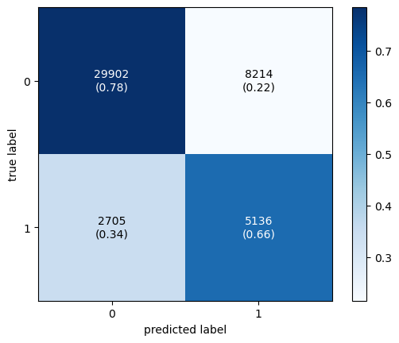

```python
# calculating and plotting the confusion matrix
cm1 = confusion_matrix(Y_test,y_pred)
plot_confusion_matrix(conf_mat=cm1,show_absolute=True,
                                show_normed=True,
                                colorbar=True)
plt.show()
```

# Part 7: Comparison

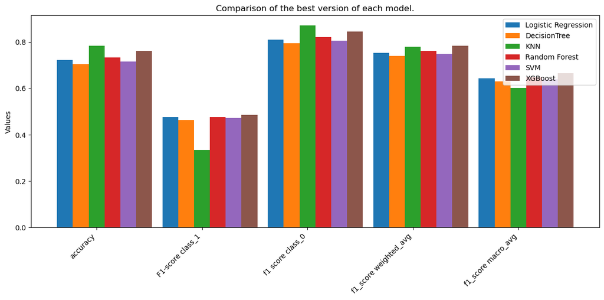

```python
import matplotlib.pyplot as plt

data = {
    'Logistic Regression': {
        'accuracy': 0.7218704441107993,
        'F1-score class_1': 0.477047704770477,
        'f1 score class_0': 0.8105584538771639,
        'f1_score weighted_avg': 0.7536561803661529,
        'f1_score macro_avg': 0.6438030793238204
    },
    'DecisionTree': {
        'accuracy': 0.7038536022803925,
        'F1-score class_1': 0.46328574808738865,
        'f1 score class_0': 0.7955105475088646,
        'f1_score weighted_avg': 0.7388276776030005,
        'f1_score macro_avg': 0.6293981477981266
    },
    'KNN': {
        'accuracy': 0.7838849359183585,
        'F1-score class_1': 0.3336911310881524,
        'f1 score class_0': 0.8710263868688968,
        'f1_score weighted_avg': 0.7793483891628495,
        'f1_score macro_avg': 0.6023587589785246
    },
    'Random Forest': {
        'accuracy': 0.7332288878734469,
        'F1-score class_1': 0.4757995553275184,
        'f1 score class_0': 0.821089805329364,
        'f1_score weighted_avg': 0.7621777603685426,
        'f1_score macro_avg': 0.6484446803284412
    },
    'SVM': {
        'accuracy': 0.7152773244554692,
        'F1-score class_1': 0.47201710850179557,
        'f1 score class_0': 0.8050825996931373,
        'f1_score weighted_avg': 0.7482562943113389,
        'f1_score macro_avg': 0.6385498540974665
    },
    'XGBoost': {
        'accuracy': 0.7624083382292143,
        'F1-score class_1': 0.4847340852248597,
        'f1 score class_0': 0.8456089249607623,
        'f1_score weighted_avg': 0.7840378994723881,
        'f1_score macro_avg': 0.6651715050928111
    }
}



categories = list(data['Logistic Regression'].keys())
num_models = len(data)
width = 0.15
positions = list(range(len(categories)))

plt.figure(figsize=(12, 6))

for i, (model, values) in enumerate(data.items()):
    values = [values.get(key, 0) for key in categories]
    plt.bar([pos + width * i for pos in positions], values, width, label=model)

#plt.xlabel('Metrics')
plt.ylabel('Values')
plt.title('Comparison of the best version of each model.')
plt.xticks([pos + width * 2 for pos in positions], categories, rotation=45, ha='right')
plt.legend()
plt.tight_layout()
plt.show()
```

```python
import pandas as pd
from sklearn.metrics import accuracy_score, precision_score, recall_score, f1_score, roc_auc_score

# Define the model names and corresponding predictions
model_names = ['Logistic regression', 'Decision Tree', 'KNN', 'Random Forest', 'SVM', 'XGBoost']
predictions = [lg_predictions, dt_predictions, knn_predictions, rf_predictions, svm_predictions, xgb_predictions]  # Replace with your actual model predictions

# Define the true labels for the test set
true_labels = Y_test  # Replace with your actual true labels

# Initialize lists to store the metric values
accuracy_values = []
precision_values = []
recall_values = []
f1_score_values = []
auc_roc_values = []

# Calculate the metrics for each model
for prediction in predictions:
    accuracy = accuracy_score(true_labels, prediction)
    precision = precision_score(true_labels, prediction)
    recall = recall_score(true_labels, prediction)
    f1 = f1_score(true_labels, prediction)
    auc_roc = roc_auc_score(true_labels, prediction)

    accuracy_values.append(accuracy)
    precision_values.append(precision)
    recall_values.append(recall)
    f1_score_values.append(f1)
    auc_roc_values.append(auc_roc)

# Create a dictionary to hold the data
results = {
    'Model': model_names,
    'Accuracy': accuracy_values,
    'Precision': precision_values,
    'Recall': recall_values,
    'F1 Score': f1_score_values,
    'AUC-ROC': auc_roc_values
}

# Create a DataFrame from the data dictionary
df = pd.DataFrame(results)

# Set the 'Model' column as the index
df.set_index('Model', inplace=True)

# Print the DataFrame
print(df)
```

```
                     Accuracy  Precision    Recall  F1 Score   AUC-ROC
Model
Logistic regression  0.721870   0.351184  0.743528  0.477048  0.730471
Decision Tree        0.693561   0.328101  0.759725  0.458284  0.719838
KNN                  0.786387   0.357555  0.316286  0.335657  0.599690
Random Forest        0.733229   0.357883  0.709603  0.475800  0.723846
SVM                  0.716235   0.346172  0.746206  0.472942  0.728138
XGBoost              0.762408   0.384719  0.655018  0.484734  0.719759
```

```python
from sklearn.metrics import roc_auc_score, precision_score, recall_score, f1_score


# Define the model names and corresponding predictions
model_names = ['Logistic regression', 'Decision Tree', 'KNN', 'Random Forest', 'SVM', 'XGBoost']
predictions = [lg_predictions, dt_predictions, knn_predictions, rf_predictions, svm_predictions, xgb_predictions]  # Replace with your actual model predictions

# Define the true labels for the test set
true_labels = Y_test  # Replace with your actual true labels

# Define the categories in your data
categories = [0, 1]  # Replace with your actual category labels

# Initialize lists to store the metric values
precision_values = []
recall_values = []
f1_score_values = []
auc_roc_values = []

# Calculate the metrics for each model and category
for prediction in predictions:
    precision = []
    recall = []
    f1 = []
    auc_roc = []

    # Calculate precision, recall, F1 score, and AUC-ROC for each category
    for category in categories:
        true_category_labels = (true_labels == category)
        predicted_category_labels = (prediction == category)

        precision.append(precision_score(true_category_labels, predicted_category_labels))
        recall.append(recall_score(true_category_labels, predicted_category_labels))
        f1.append(f1_score(true_category_labels, predicted_category_labels))
        auc_roc.append(roc_auc_score(true_category_labels, predicted_category_labels))

    precision_values.append(precision)
    recall_values.append(recall)
    f1_score_values.append(f1)
    auc_roc_values.append(auc_roc)

# Create a dictionary to hold the data
data = {
    'Model': model_names,
    f'Precision for Not-Diabetic Group': [precision[0] for precision in precision_values],
    f'Precision for Diabetic Group': [precision[1] for precision in precision_values],
    f'Recall for Not-Diabetic Group': [recall[0] for recall in recall_values],
    f'Recall for Diabetic Group': [recall[1] for recall in recall_values],
    f'F1 Score for Not-Diabetic Group': [f1[0] for f1 in f1_score_values],
    f'F1 Score for Diabetic Group': [f1[1] for f1 in f1_score_values],
    f'AUC-ROC for Not-Diabetic Group': [auc[0] for auc in auc_roc_values],
    f'AUC-ROC for Diabetic Group': [auc[1] for auc in auc_roc_values]
}

# Create a DataFrame from the data dictionary
df = pd.DataFrame(data)

# Set the 'Model' column as the index
df.set_index('Model', inplace=True)

# Print the DataFrame
print(df)
```

```
                     Precision for Not-Diabetic Group  \
Model
Logistic regression                          0.931496
Decision Tree                                0.932233
KNN                                          0.862612
Random Forest                                0.925123
SVM                                          0.931509
XGBoost                                      0.917042

                     Precision for Diabetic Group  \
Model
Logistic regression                      0.351184
Decision Tree                            0.328101
KNN                                      0.357555
Random Forest                            0.357883
SVM                                      0.346172
XGBoost                                  0.384719

                     Recall for Not-Diabetic Group  Recall for Diabetic Group  \
Model
Logistic regression                       0.717415                   0.743528
Decision Tree                             0.679951                   0.759725
KNN                                       0.883094                   0.316286
Random Forest                             0.738089                   0.709603
SVM                                       0.710069                   0.746206
XGBoost                                   0.784500                   0.655018

                     F1 Score for Not-Diabetic Group  \
Model
Logistic regression                         0.810558
Decision Tree                               0.786353
KNN                                         0.872733
Random Forest                               0.821090
SVM                                         0.805854
XGBoost                                     0.845609

                     F1 Score for Diabetic Group  \
Model
Logistic regression                     0.477048
Decision Tree                           0.458284
KNN                                     0.335657
Random Forest                           0.475800
SVM                                     0.472942
XGBoost                                 0.484734

                     AUC-ROC for Not-Diabetic Group  \
Model
Logistic regression                        0.730471
Decision Tree                              0.719838
KNN                                        0.599690
Random Forest                              0.723846
SVM                                        0.728138
XGBoost                                    0.719759

                     AUC-ROC for Diabetic Group
Model
Logistic regression                    0.730471
Decision Tree                          0.719838
KNN                                    0.599690
Random Forest                          0.723846
SVM                                    0.728138
XGBoost                                0.719759
```

```python
import pandas as pd
from sklearn.metrics import roc_auc_score, precision_score, recall_score, f1_score
from IPython.display import display


# Define the model names and corresponding predictions
model_names = ['Logistic regression', 'Decision Tree', 'KNN', 'Random Forest', 'SVM', 'XGBoost']
predictions = [lg_predictions, dt_predictions, knn_predictions, rf_predictions, svm_predictions, xgb_predictions]  # Replace with your actual model predictions

# Define the true labels for the test set
true_labels = Y_test  # Replace with your actual true labels

# Define the categories in your data
categories = [0, 1]  # Replace with your actual category labels

# Initialize lists to store the metric values
metrics = ['Precision', 'Recall', 'F1 Score', 'AUC-ROC']
metric_values = [[] for _ in range(len(metrics))]

# Calculate the metrics for each model and category
for prediction in predictions:
    model_metric_values = [[] for _ in range(len(metrics))]

    # Calculate metric values for each category
    for category in categories:
        true_category_labels = (true_labels == category)
        predicted_category_labels = (prediction == category)

        model_metric_values[0].append(precision_score(true_category_labels, predicted_category_labels))
        model_metric_values[1].append(recall_score(true_category_labels, predicted_category_labels))
        model_metric_values[2].append(f1_score(true_category_labels, predicted_category_labels))
        model_metric_values[3].append(roc_auc_score(true_category_labels, predicted_category_labels))

    # Append model metric values to the overall metric values
    for i in range(len(metrics)):
        metric_values[i].extend(model_metric_values[i])

# Create a dictionary to hold the data
data = {
    'Model': model_names
}

# Add metric values for each category to the data dictionary
for i in range(len(metrics)):
    metric_name = metrics[i]
    category_names = ['Not-Diabetic Group', 'Diabetic Group']

    for j in range(len(category_names)):
        category_name = category_names[j]
        column_name = f'{metric_name} - {category_name}'
        data[column_name] = metric_values[i][j::2]

# Create a DataFrame from the data dictionary
df = pd.DataFrame(data)

# Set the 'Model' column as the index
df.set_index('Model', inplace=True)

# Format the table headings and model names as bold
df_styled = df.style.set_table_styles([{'selector': 'th', 'props': [('font-weight', 'bold')]}])

# Display the styled DataFrame
display(df_styled)
```

| Model | Precision - Not-Diabetic Group | Precision - Diabetic Group | Recall - Not-Diabetic Group | Recall - Diabetic Group | F1 Score - Not-Diabetic Group | F1 Score - Diabetic Group | AUC-ROC - Not-Diabetic Group | AUC-ROC - Diabetic Group |
| --- | --- | --- | --- | --- | --- | --- | --- | --- |
| Logistic regression | 0.931496 | 0.351184 | 0.717415 | 0.743528 | 0.810558 | 0.477048 | 0.730471 | 0.730471 |
| Decision Tree | 0.932233 | 0.328101 | 0.679951 | 0.759725 | 0.786353 | 0.458284 | 0.719838 | 0.719838 |
| KNN | 0.862612 | 0.357555 | 0.883094 | 0.316286 | 0.872733 | 0.335657 | 0.599690 | 0.599690 |
| Random Forest | 0.925123 | 0.357883 | 0.738089 | 0.709603 | 0.821090 | 0.475800 | 0.723846 | 0.723846 |
| SVM | 0.931509 | 0.346172 | 0.710069 | 0.746206 | 0.805854 | 0.472942 | 0.728138 | 0.728138 |
| XGBoost | 0.917042 | 0.384719 | 0.784500 | 0.655018 | 0.845609 | 0.484734 | 0.719759 | 0.719759 |

# Comparing Two of the Best Models

```python
from tabulate import tabulate
import pandas as pd
data = {
    'KNN': {
        'accuracy': 0.7838849359183585,
        'F1-score class_1': 0.3336911310881524,
        'f1 score class_0': 0.8710263868688968,
        'f1_score weighted_avg': 0.7793483891628495,
        'f1_score macro_avg': 0.6023587589785246
    },
    'XGBoost': {
        'accuracy': 0.7624083382292143,
        'F1-score class_1': 0.4847340852248597,
        'f1 score class_0': 0.8456089249607623,
        'f1_score weighted_avg': 0.7840378994723881,
        'f1_score macro_avg': 0.6651715050928111
    }
}
df = pd.DataFrame(data)
table = tabulate(df, headers='keys', tablefmt='pretty')
print(table)
```

```
+-----------------------+--------------------+--------------------+
|                       |        KNN         |      XGBoost       |
+-----------------------+--------------------+--------------------+
|       accuracy        | 0.7838849359183585 | 0.7624083382292143 |
|   F1-score class_1    | 0.3336911310881524 | 0.4847340852248597 |
|   f1 score class_0    | 0.8710263868688968 | 0.8456089249607623 |
| f1_score weighted_avg | 0.7793483891628495 | 0.7840378994723881 |
|  f1_score macro_avg   | 0.6023587589785246 | 0.6651715050928111 |
+-----------------------+--------------------+--------------------+
```

# Save the Output

```python
#!jupyter nbconvert Diabetes-v3.ipynb  --to html
```

[output not shown]